# Project 5: Communicate Data Findings

Bay Wheels is a regional public bicycle sharing system operated by Motivate in partnership with the Metropolitan Transportation Commission and the Bay Area Air Quality Management District, in the San Francisco Bay Area, California.

Bay Wheels is the first national and large-scale cycling sharing program to be deployed both in California and on the US West Coast. It was founded in August 2013 as Bay Area Bike Share. The Bay Wheels network had more than 2600 bicycles in 262 stations across San Francisco, East Bay and San Jose.

The system officially re-launched on 28 June 2017 in a partnership with Ford Motor Company as Ford GoBike. The system was subsequently renamed to Bay Wheels in June 2019 following Lyft 's acquisition of Motivate. The network is planned to extend to about 540 stations in San Francisco, Oakland, Berkeley, Emeryville and San Jose to 7,000 bicycles.

## Preliminary Wrangling

```python
# import all packages and set plots to be embedded inline
import numpy as np
import pandas as pd
import matplotlib.pyplot as plt
import seaborn as sb
from datetime import datetime
import os
import glob
import zipfile
import datetime
import folium
from sklearn.cluster import KMeans

%matplotlib inline
```

### Gathering and Assessing Data

```python
# only ran once to append all monthly trip data together

folder_name = 'Data'
frames = [pd.read_csv(f) for f in glob.glob(os.path.join(folder_name, '*.csv'))]
result = pd.concat(frames, ignore_index=True)
print(result.shape)
result.sample(5)
```

```
(1863721, 16)
```

|  | duration_sec | start_time | end_time | start_station_id | start_station_name | start_station_latitude | start_station_longitude | end_station_id | end_station_name | end_station_latitude | end_station_longitude | bike_id | user_type | member_birth_year | member_gender | bike_share_for_all_trip |
| --- | --- | --- | --- | --- | --- | --- | --- | --- | --- | --- | --- | --- | --- | --- | --- | --- |
| 297528 | 137 | 2018-03-06 11:50:54.7170 | 2018-03-06 11:53:11.9610 | 312.0 | San Jose Diridon Station | 37.329732 | -121.901782 | 283.0 | Delmas Ave and San Fernando St | 37.330264 | -121.897702 | 48 | Subscriber | 1982.0 | Male | No |
| 1573381 | 735 | 2018-10-04 09:40:26.4190 | 2018-10-04 09:52:42.2550 | 181.0 | Grand Ave at Webster St | 37.811377 | -122.265192 | 193.0 | Grand Ave at Santa Clara Ave | 37.812744 | -122.247215 | 2115 | Subscriber | 1966.0 | Female | No |
| 225259 | 224 | 2018-03-26 20:26:52.8100 | 2018-03-26 20:30:36.8630 | 36.0 | Folsom St at 3rd St | 37.783830 | -122.398870 | 26.0 | 1st St at Folsom St | 37.787290 | -122.394380 | 1456 | Subscriber | 1995.0 | Male | No |
| 1136775 | 386 | 2018-08-13 06:24:45.4420 | 2018-08-13 06:31:12.4000 | 214.0 | Market St at Brockhurst St | 37.823321 | -122.275732 | 192.0 | MLK Jr Way at 36th St (Temporary Location) | 37.825794 | -122.269399 | 1546 | Subscriber | 1988.0 | Male | No |
| 1602919 | 282 | 2018-11-30 08:44:15.5700 | 2018-11-30 08:48:57.7990 | 244.0 | Shattuck Ave at Hearst Ave | 37.873676 | -122.268487 | 251.0 | California St at University Ave | 37.870555 | -122.279720 | 2949 | Subscriber | 1977.0 | Male | No |

```python
# save the appended result to a .csv for further usage

result.to_csv('fordgobike_trips_2018.csv', index=False)
```

```python
biketrips2018 = pd.read_csv('fordgobike_trips_2018.csv')
biketrips2018.head()
```

|  | duration_sec | start_time | end_time | start_station_id | start_station_name | start_station_latitude | start_station_longitude | end_station_id | end_station_name | end_station_latitude | end_station_longitude | bike_id | user_type | member_birth_year | member_gender | bike_share_for_all_trip |
| --- | --- | --- | --- | --- | --- | --- | --- | --- | --- | --- | --- | --- | --- | --- | --- | --- |
| 0 | 75284 | 2018-01-31 22:52:35.2390 | 2018-02-01 19:47:19.8240 | 120.0 | Mission Dolores Park | 37.761420 | -122.426435 | 285.0 | Webster St at O'Farrell St | 37.783521 | -122.431158 | 2765 | Subscriber | 1986.0 | Male | No |
| 1 | 85422 | 2018-01-31 16:13:34.3510 | 2018-02-01 15:57:17.3100 | 15.0 | San Francisco Ferry Building (Harry Bridges Pl... | 37.795392 | -122.394203 | 15.0 | San Francisco Ferry Building (Harry Bridges Pl... | 37.795392 | -122.394203 | 2815 | Customer | NaN | NaN | No |
| 2 | 71576 | 2018-01-31 14:23:55.8890 | 2018-02-01 10:16:52.1160 | 304.0 | Jackson St at 5th St | 37.348759 | -121.894798 | 296.0 | 5th St at Virginia St | 37.325998 | -121.877120 | 3039 | Customer | 1996.0 | Male | No |
| 3 | 61076 | 2018-01-31 14:53:23.5620 | 2018-02-01 07:51:20.5000 | 75.0 | Market St at Franklin St | 37.773793 | -122.421239 | 47.0 | 4th St at Harrison St | 37.780955 | -122.399749 | 321 | Customer | NaN | NaN | No |
| 4 | 39966 | 2018-01-31 19:52:24.6670 | 2018-02-01 06:58:31.0530 | 74.0 | Laguna St at Hayes St | 37.776435 | -122.426244 | 19.0 | Post St at Kearny St | 37.788975 | -122.403452 | 617 | Subscriber | 1991.0 | Male | No |

```python
biketrips2018.info()
```

```
<class 'pandas.core.frame.DataFrame'>
RangeIndex: 1863721 entries, 0 to 1863720
Data columns (total 16 columns):
 #   Column                   Dtype
---  ------                   -----
 0   duration_sec             int64
 1   start_time               object
 2   end_time                 object
 3   start_station_id         float64
 4   start_station_name       object
 5   start_station_latitude   float64
 6   start_station_longitude  float64
 7   end_station_id           float64
 8   end_station_name         object
 9   end_station_latitude     float64
 10  end_station_longitude    float64
 11  bike_id                  int64
 12  user_type                object
 13  member_birth_year        float64
 14  member_gender            object
 15  bike_share_for_all_trip  object
dtypes: float64(7), int64(2), object(7)
memory usage: 227.5+ MB
```

Datatype of start_time, end_time are String but it should be DateTime.

We need to analyze bike_id, user_type, so it should be a categorical variable.

```python
biketrips2018.isnull().sum()
```

```
duration_sec                    0
start_time                      0
end_time                        0
start_station_id            11771
start_station_name          11771
start_station_latitude          0
start_station_longitude         0
end_station_id              11771
end_station_name            11771
end_station_latitude            0
end_station_longitude           0
bike_id                         0
user_type                       0
member_birth_year          110718
member_gender              110367
bike_share_for_all_trip         0
dtype: int64
```

```python
biketrips2018.duplicated().sum()
```

```
0
```

```python
biketrips2018.member_gender.value_counts()
```

```
Male      1288085
Female     438188
Other       27081
Name: member_gender, dtype: int64
```

```python
biketrips2018.user_type.value_counts()
```

```
Subscriber    1583554
Customer       280167
Name: user_type, dtype: int64
```

```python
biketrips2018.bike_share_for_all_trip.value_counts()
```

```
No     1701386
Yes     162335
Name: bike_share_for_all_trip, dtype: int64
```

```python
biketrips2018.shape
```

```
(1863721, 16)
```

```python
# make a copy of the dataframe
trips18 = biketrips2018.copy()
```

```python
trips18.info()
```

```
<class 'pandas.core.frame.DataFrame'>
RangeIndex: 1863721 entries, 0 to 1863720
Data columns (total 16 columns):
 #   Column                   Dtype
---  ------                   -----
 0   duration_sec             int64
 1   start_time               object
 2   end_time                 object
 3   start_station_id         float64
 4   start_station_name       object
 5   start_station_latitude   float64
 6   start_station_longitude  float64
 7   end_station_id           float64
 8   end_station_name         object
 9   end_station_latitude     float64
 10  end_station_longitude    float64
 11  bike_id                  int64
 12  user_type                object
 13  member_birth_year        float64
 14  member_gender            object
 15  bike_share_for_all_trip  object
dtypes: float64(7), int64(2), object(7)
memory usage: 227.5+ MB
```

### Cleaning Data

**Define 1**  
*start_station_id, start_station_name, end_station_id, end_station_name, member_birth_year* and *member_gender* columns have missing values

```python
# Check coordinates for rows with missing start/end station names and id
print(trips18[trips18.start_station_id.isnull()].start_station_latitude.value_counts())
print(trips18[trips18.start_station_id.isnull()].start_station_longitude.value_counts())
```

```
37.41    4809
37.40    4395
37.42    1204
37.39     822
37.38     405
37.34      37
37.43      23
37.37      17
37.35      17
37.33      17
37.36       8
45.51       4
40.66       3
37.44       3
37.32       2
44.95       2
45.50       2
37.45       1
Name: start_station_latitude, dtype: int64
-121.94    4047
-121.93    2790
-121.96    1948
-121.95    1537
-121.92    1250
-121.97      51
-121.91      40
-121.98      31
-121.90      25
-121.89      21
-121.88       8
-73.57        6
-121.87       4
-121.84       3
-74.01        3
-121.86       3
-93.22        2
-121.83       1
-121.99       1
Name: start_station_longitude, dtype: int64
```

> All those rows with missing values should be dropped. Most rows with missing start/end id and station name have similar coordinates. Also those rows have lower accuracy of coordinates with only 2 decimal points

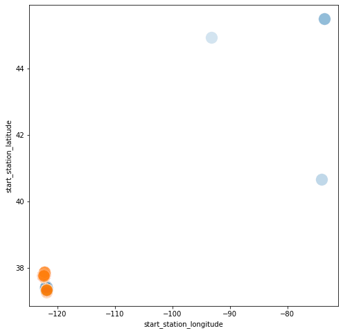

```python
# Plotting missing start/end id and station name
plt.figure(figsize=(8,8))
sb.scatterplot(data = trips18[trips18.start_station_id.isnull()],
                x = "start_station_longitude",
                y = "start_station_latitude",
                s = 300, alpha = 0.1)
sb.scatterplot(data = trips18.dropna(subset=["start_station_id"]).sample(100000),
                x = "start_station_longitude",
                y = "start_station_latitude",
                s = 300, alpha = 0.1);
```

> Only consider coordinates that are located in Bay Area. Outlier should be removed and not useful for the analysis.

### Code 1

```python
# Make copy of original df and drop rows with missing values
trips18_clean = trips18.dropna()
```

```python
# Remove all the coordinates outside Bay Area
trips18_clean = trips18_clean.query('end_station_latitude > 37 and end_station_latitude < 38 and end_station_longitude > -123 and end_station_longitude < -121 and start_station_latitude > 37 and start_station_latitude < 38 and start_station_longitude > -123 and start_station_longitude < -121')
```

### Test 1

```python
# Check for missing values
trips18_clean.isna().sum().any()
```

```
False
```

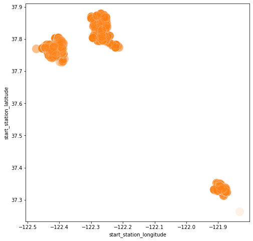

```python
# Plotting no missing data df start/end id and station name
plt.figure(figsize=(8,8))
sb.scatterplot(data = trips18_clean[trips18_clean.start_station_id.isnull()],
                x = "start_station_longitude",
                y = "start_station_latitude",
                s = 300, alpha = 0.1)
sb.scatterplot(data = trips18_clean.dropna(subset=["start_station_id"]).sample(100000),
                x = "start_station_longitude",
                y = "start_station_latitude",
                s = 300, alpha = 0.1);
```

> Above graph shows the 3 main areas of GoBike: *SF, SJ* and *East Bay*.  
> *start_metro_area* and *start_metro_area* columns should be added to label each station

**Define 1.1**  
*start_metro_area* and *end_metro_area* columns should be added to label strat and end stations

**Code 1.1**

```python
# Using sklean module's K-Mean clustering algorithm to label each start/end stations
# Start staion
kmeans_start = KMeans(n_clusters=3, random_state=0).fit(trips18_clean[["start_station_latitude", "start_station_longitude"]])
trips18_clean['start_metro_area'] = kmeans_start.labels_
trips18_clean['start_metro_area'].replace({0:'East Bay', 1:'San Jose', 2:'San Francisco'}, inplace=True) # Hard coding the labels
                                                                                                    # set random_state = 0
```

```python
# End station
kmeans_end = KMeans(n_clusters=3, random_state=0).fit(trips18_clean[["end_station_latitude", "end_station_longitude"]])
trips18_clean['end_metro_area'] = kmeans_end.labels_
trips18_clean['end_metro_area'].replace({0:'East Bay', 1:'San Francisco', 2:'San Jose'}, inplace=True)   # Hard coding the labels
                                                                                                    # set random_state = 0
```

**Test 1.1**

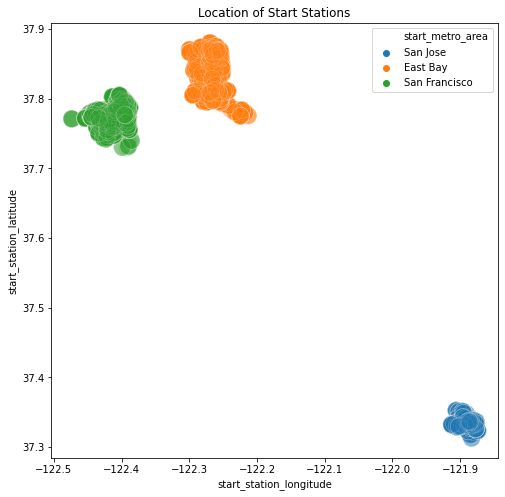

```python
# Plotting start station coordinates
plt.figure(figsize=(8,8))
plt.title('Location of Start Stations')
sb.scatterplot(data = trips18_clean.sample(100000),
                x = "start_station_longitude",
                y = "start_station_latitude",
                hue = "start_metro_area",
                s=300, alpha = 0.1);
```

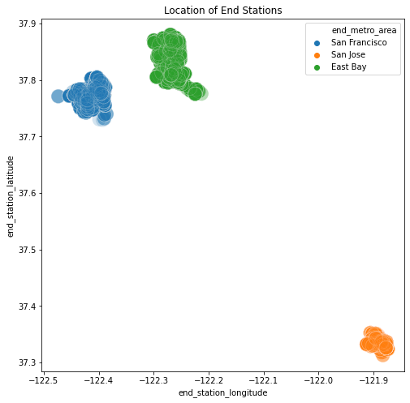

```python
# Plotting end station coordinates
plt.figure(figsize=(8,8))
plt.title('Location of End Stations')
sb.scatterplot(data = trips18_clean.sample(100000),
                x = "end_station_longitude",
                y = "end_station_latitude",
                hue = "end_metro_area",
                s=300, alpha = 0.1);
```

**Define 2**  
**`start_time`** and **`end_time`** should be converted to datetime data type

**Code 2**

```python
# Converted to datetime

# Change start_time and end_time to datetime format
trips18_clean.start_time = pd.to_datetime(trips18_clean.start_time)
trips18_clean.end_time = pd.to_datetime(trips18_clean.end_time)
```

**Test 2**

```python
trips18_clean.dtypes
```

```
duration_sec                        int64
start_time                 datetime64[ns]
end_time                   datetime64[ns]
start_station_id                  float64
start_station_name                 object
start_station_latitude            float64
start_station_longitude           float64
end_station_id                    float64
end_station_name                   object
end_station_latitude              float64
end_station_longitude             float64
bike_id                             int64
user_type                          object
member_birth_year                 float64
member_gender                      object
bike_share_for_all_trip            object
start_metro_area                   object
end_metro_area                     object
dtype: object
```

**Define 3**  
**`month`**, **`weekday`** and **`hours`** column should be added for analysis

**Code 3**

```python
# Create month column
trips18_clean['month'] = trips18_clean['start_time'].dt.month

# Create month column
trips18_clean['weekday'] = trips18_clean['start_time'].dt.weekday.astype('category')

# Create month column
trips18_clean['hour'] = trips18_clean['start_time'].dt.hour
```

**Test 3**

```python
trips18_clean[['month','weekday','hour']].sample(5)
```

|  | month | weekday | hour |
| --- | --- | --- | --- |
| 720116 | 6 | 5 | 12 |
| 222068 | 3 | 1 | 16 |
| 367054 | 4 | 3 | 18 |
| 221785 | 3 | 1 | 17 |
| 1452073 | 10 | 1 | 13 |

**Define 4**  
**`start_station_id`**, **`end_station_id`**, **`member_birth_year`** should be data type int

**Code 4**

```python
trips18_clean['start_station_id']=trips18_clean['start_station_id'].astype('int')
trips18_clean['end_station_id']=trips18_clean['end_station_id'].astype('int')
trips18_clean['member_birth_year']=trips18_clean['member_birth_year'].astype('int')
```

**Test 4**

```python
trips18_clean.dtypes
```

```
duration_sec                        int64
start_time                 datetime64[ns]
end_time                   datetime64[ns]
start_station_id                    int32
start_station_name                 object
start_station_latitude            float64
start_station_longitude           float64
end_station_id                      int32
end_station_name                   object
end_station_latitude              float64
end_station_longitude             float64
bike_id                             int64
user_type                          object
member_birth_year                   int32
member_gender                      object
bike_share_for_all_trip            object
start_metro_area                   object
end_metro_area                     object
month                               int64
weekday                          category
hour                                int64
dtype: object
```

**Define 5**  
**`member_birth_year`** should be converted to **`member_age`**

**Code 5**

```python
# Get year when member use the bike
trips18_clean['start_time'].dt.year.value_counts()
```

```
2018    1741556
Name: start_time, dtype: int64
```

```python
# Add member_age column
trips18_clean['member_age'] = trips18_clean['start_time'].dt.year - trips18_clean['member_birth_year']
```

**Test 5**

```python
# Check for null
trips18_clean['member_age'].isna().sum()
```

```
0
```

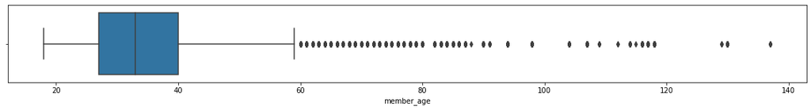

```python
# Plot member age distibution
plt.figure(figsize = [20, 2])
base_color = sb.color_palette()[0]
sb.boxplot(data=trips18_clean, x='member_age', color=base_color);
```

```python
trips18_clean.member_age.describe(percentiles = [0.01, 0.05, 0.95, 0.99])
```

```
count    1.741556e+06
mean     3.493921e+01
std      1.045133e+01
min      1.800000e+01
1%       1.900000e+01
5%       2.200000e+01
50%      3.300000e+01
95%      5.600000e+01
99%      6.500000e+01
max      1.370000e+02
Name: member_age, dtype: float64
```

> From above, the youngest users are 18 which makes sense. However, 95% percentile combined with box plot shows older users above 55 year old seems to be outliers. It is logical that rows above 60 yrs old should be removed.

**Define 5.1**  
**`member_age`** outlier should be removed

**Code 5.1**

```python
# Remove all rows with age <= 60
trips18_clean = trips18_clean.query('member_age <= 60')
```

**Test 5.1**

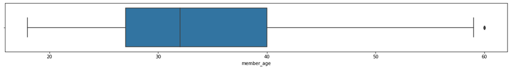

```python
# Plot member age <= 60 yrs distibution
plt.figure(figsize = [20, 2])
base_color = sb.color_palette()[0]
sb.boxplot(data=trips18_clean, x='member_age', color=base_color);
```

**Define 5.2**  
Add **`age_group`** label column

**Code 5.2**

```python
# Add age_group label column
labels = ["{}s".format(i) for i in range(10,51,10)]
trips18_clean['age_group'] = pd.cut(trips18_clean['member_age'], range(10, 61, 10), right=True, labels=labels)
```

**Test 5.2**

```python
# Test member age and their age_group
trips18_clean[['age_group','member_age']].sample(5)
```

|  | age_group | member_age |
| --- | --- | --- |
| 133194 | 30s | 38 |
| 509995 | 20s | 28 |
| 544051 | 20s | 24 |
| 728821 | 30s | 31 |
| 301696 | 30s | 34 |

```python
trips18_clean['age_group'].isna().any()
```

```
False
```

**Define 6**  
**`bike_share_for_all_trip`** column should be boolean

```python
trips18_clean.bike_share_for_all_trip.replace({'Yes':True, 'No':False}, inplace=True)
```

**Test 6**

```python
trips18_clean.bike_share_for_all_trip.dtypes
```

```
dtype('bool')
```

**Define 7**  
**`user_type`**, **`member_gender`**, **`age_group`**, **`month`**, **`weekday`** and **`hour`** should be categorical variables

**Code 7**

```python
# Converted to categorical
trips18_clean['user_type']=trips18_clean['user_type'].astype('category')
trips18_clean['member_gender']=trips18_clean['member_gender'].astype('category')
trips18_clean['age_group']=trips18_clean['age_group'].astype('category')
trips18_clean['month']=trips18_clean['month'].astype('category')
trips18_clean['weekday']=trips18_clean['weekday'].astype('category')
trips18_clean['hour']=trips18_clean['hour'].astype('category')
trips18_clean['start_metro_area']=trips18_clean['start_metro_area'].astype('category')
trips18_clean['end_metro_area']=trips18_clean['end_metro_area'].astype('category')
```

**Test 7**

```python
trips18_clean.dtypes
```

```
duration_sec                        int64
start_time                 datetime64[ns]
end_time                   datetime64[ns]
start_station_id                    int32
start_station_name                 object
start_station_latitude            float64
start_station_longitude           float64
end_station_id                      int32
end_station_name                   object
end_station_latitude              float64
end_station_longitude             float64
bike_id                             int64
user_type                        category
member_birth_year                   int32
member_gender                    category
bike_share_for_all_trip              bool
start_metro_area                 category
end_metro_area                   category
month                            category
weekday                          category
hour                             category
member_age                          int64
age_group                        category
dtype: object
```

```python
trips18_clean.member_gender.value_counts()
```

```
Male      1249454
Female     429039
Other       26419
Name: member_gender, dtype: int64
```

**Define 8**  
**`duration_sec`** has many large values maybe outlier due to customers forgot to log off after using

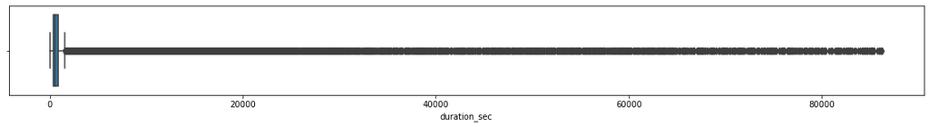

```python
# Plot duration distibution
plt.figure(figsize = [20, 2])
base_color = sb.color_palette()[0]
sb.boxplot(data=trips18_clean, x='duration_sec', color=base_color);
```

```python
trips18_clean.duration_sec.describe(percentiles = [0.01, 0.05, 0.95, 0.99])
```

```
count    1.704912e+06
mean     7.721736e+02
std      1.943831e+03
min      6.100000e+01
1%       1.060000e+02
5%       1.760000e+02
50%      5.420000e+02
95%      1.642000e+03
99%      3.858000e+03
max      8.628100e+04
Name: duration_sec, dtype: float64
```

**Code 8**

```python
# Remove duration outliers
trips18_clean = trips18_clean.query('duration_sec <= 6000')
```

**Test 8**

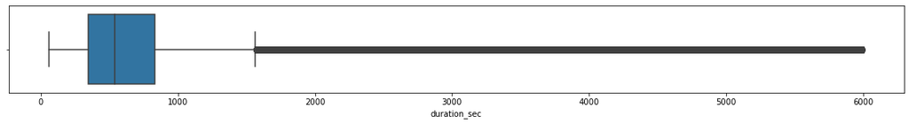

```python
# Plot duration < 6000 sec distibution
plt.figure(figsize = [20, 2])
base_color = sb.color_palette()[0]
sb.boxplot(data=trips18_clean, x='duration_sec', color=base_color);
```

**Define 9**  
Set orders of categorical variables: **`age_group`**, **`member_gender`**, **`weekday`** and **`month`**

**Code 9**

```python
# Set order of each categorical variable

# age_group
trips18_clean['age_group'] = pd.Categorical(trips18_clean['age_group'], ['10s', '20s', '30s', '40s', '50s'])
# member_gender
trips18_clean['member_gender'] = pd.Categorical(trips18_clean['member_gender'], ['Male','Female','Other'])
# weekday
trips18_clean['weekday'] = pd.Categorical(trips18_clean['weekday'], ['Monday','Tuesday','Wednesday','Thursday','Friday','Saturday','Sunday'])
# month
trips18_clean['month'] = pd.Categorical(trips18_clean['month'], [6,7,8,9,10,11,12,1,2,3,4,5])
```

**Test 9**

```python
trips18_clean.weekday.value_counts().index.categories
```

```
Index(['Monday', 'Tuesday', 'Wednesday', 'Thursday', 'Friday', 'Saturday',
       'Sunday'],
      dtype='object')
```

```python
# Final df_clean
trips18_clean.info()
```

```
<class 'pandas.core.frame.DataFrame'>
Int64Index: 1695316 entries, 6 to 1863719
Data columns (total 23 columns):
 #   Column                   Dtype
---  ------                   -----
 0   duration_sec             int64
 1   start_time               datetime64[ns]
 2   end_time                 datetime64[ns]
 3   start_station_id         int32
 4   start_station_name       object
 5   start_station_latitude   float64
 6   start_station_longitude  float64
 7   end_station_id           int32
 8   end_station_name         object
 9   end_station_latitude     float64
 10  end_station_longitude    float64
 11  bike_id                  int64
 12  user_type                category
 13  member_birth_year        int32
 14  member_gender            category
 15  bike_share_for_all_trip  bool
 16  start_metro_area         category
 17  end_metro_area           category
 18  month                    category
 19  weekday                  category
 20  hour                     category
 21  member_age               int64
 22  age_group                category
dtypes: bool(1), category(8), datetime64[ns](2), float64(4), int32(3), int64(3), object(2)
memory usage: 189.2+ MB
```

```python
# trips18.info()
```

```python
# # issue 2: add new columns for trip duration in minute, trip start date in yyyy-mm-dd format, trip start hour of the day, day of week and month

trips18_clean['duration_minute'] = trips18_clean['duration_sec']/60

trips18_clean['start_date'] = trips18_clean.start_time.dt.strftime('%Y-%m-%d')
trips18_clean['start_hourofday'] = trips18_clean.start_time.dt.strftime('%H')
trips18_clean['start_dayofweek'] = trips18_clean.start_time.dt.strftime('%A')
trips18_clean['start_month'] = trips18_clean.start_time.dt.strftime('%B')

trips18_clean.head()
```

|  | duration_sec | start_time | end_time | start_station_id | start_station_name | start_station_latitude | start_station_longitude | end_station_id | end_station_name | end_station_latitude | ... | month | weekday | hour | member_age | age_group | duration_minute | start_date | start_hourofday | start_dayofweek | start_month |
| --- | --- | --- | --- | --- | --- | --- | --- | --- | --- | --- | --- | --- | --- | --- | --- | --- | --- | --- | --- | --- | --- |
| 6 | 453 | 2018-01-31 23:53:53.632 | 2018-02-01 00:01:26.805 | 110 | 17th & Folsom Street Park (17th St at Folsom St) | 37.763708 | -122.415204 | 134 | Valencia St at 24th St | 37.752428 | ... | 1 | NaN | 23 | 30 | 20s | 7.55 | 2018-01-31 | 23 | Wednesday | January |
| 7 | 180 | 2018-01-31 23:52:09.903 | 2018-01-31 23:55:10.807 | 81 | Berry St at 4th St | 37.775880 | -122.393170 | 93 | 4th St at Mission Bay Blvd S | 37.770407 | ... | 1 | NaN | 23 | 38 | 30s | 3.00 | 2018-01-31 | 23 | Wednesday | January |
| 8 | 996 | 2018-01-31 23:34:56.004 | 2018-01-31 23:51:32.674 | 134 | Valencia St at 24th St | 37.752428 | -122.420628 | 4 | Cyril Magnin St at Ellis St | 37.785881 | ... | 1 | NaN | 23 | 31 | 30s | 16.60 | 2018-01-31 | 23 | Wednesday | January |
| 9 | 825 | 2018-01-31 23:34:14.027 | 2018-01-31 23:47:59.809 | 305 | Ryland Park | 37.342725 | -121.895617 | 317 | San Salvador St at 9th St | 37.333955 | ... | 1 | NaN | 23 | 24 | 20s | 13.75 | 2018-01-31 | 23 | Wednesday | January |
| 11 | 432 | 2018-01-31 23:34:26.484 | 2018-01-31 23:41:39.297 | 89 | Division St at Potrero Ave | 37.769218 | -122.407646 | 43 | San Francisco Public Library (Grove St at Hyde... | 37.778768 | ... | 1 | NaN | 23 | 25 | 20s | 7.20 | 2018-01-31 | 23 | Wednesday | January |

5 rows × 28 columns

```python
# issue 3: add a new column calculating riders' age from 'member_birth_year'

trips18_clean['member_age'] = 2019 - trips18_clean['member_birth_year']
trips18_clean.describe()
```

|  | duration_sec | start_station_id | start_station_latitude | start_station_longitude | end_station_id | end_station_latitude | end_station_longitude | bike_id | member_birth_year | member_age | duration_minute |
| --- | --- | --- | --- | --- | --- | --- | --- | --- | --- | --- | --- |
| count | 1.695316e+06 | 1.695316e+06 | 1.695316e+06 | 1.695316e+06 | 1.695316e+06 | 1.695316e+06 | 1.695316e+06 | 1.695316e+06 | 1.695316e+06 | 1.695316e+06 | 1.695316e+06 |
| mean | 6.733463e+02 | 1.204515e+02 | 3.776863e+01 | -1.223512e+02 | 1.188763e+02 | 3.776873e+01 | -1.223507e+02 | 2.293644e+03 | 1.983762e+03 | 3.523811e+01 | 1.122244e+01 |
| std | 5.418813e+02 | 1.001461e+02 | 1.016470e-01 | 1.194266e-01 | 1.001396e+02 | 1.014922e-01 | 1.188235e-01 | 1.287884e+03 | 9.264464e+00 | 9.264464e+00 | 9.031355e+00 |
| min | 6.100000e+01 | 3.000000e+00 | 3.726331e+01 | -1.224737e+02 | 3.000000e+00 | 3.726331e+01 | -1.224737e+02 | 1.100000e+01 | 1.958000e+03 | 1.900000e+01 | 1.016667e+00 |
| 25% | 3.430000e+02 | 3.600000e+01 | 3.777106e+01 | -1.224116e+02 | 3.000000e+01 | 3.777106e+01 | -1.224094e+02 | 1.222000e+03 | 1.978000e+03 | 2.800000e+01 | 5.716667e+00 |
| 50% | 5.400000e+02 | 8.900000e+01 | 3.778107e+01 | -1.223974e+02 | 8.900000e+01 | 3.778107e+01 | -1.223971e+02 | 2.334000e+03 | 1.986000e+03 | 3.300000e+01 | 9.000000e+00 |
| 75% | 8.310000e+02 | 1.860000e+02 | 3.779625e+01 | -1.222876e+02 | 1.860000e+02 | 3.779728e+01 | -1.222894e+02 | 3.328000e+03 | 1.991000e+03 | 4.100000e+01 | 1.385000e+01 |
| max | 6.000000e+03 | 3.810000e+02 | 3.788022e+01 | -1.218333e+02 | 3.810000e+02 | 3.788022e+01 | -1.218333e+02 | 6.234000e+03 | 2.000000e+03 | 6.100000e+01 | 1.000000e+02 |

```python
# # issue 4: filter out outlier ages from visually examination of the distribution above
# # issue 5: cast 'member_birth_year' and 'member_age' to integer instead of float type

trips18_clean = trips18_clean.query('member_age <= 70')
trips18_clean['member_birth_year'] = trips18_clean['member_birth_year'].astype('int')
trips18_clean['member_age'] = trips18_clean['member_age'].astype('int')
trips18_clean.info(null_counts=True)
```

```
<class 'pandas.core.frame.DataFrame'>
Int64Index: 1695316 entries, 6 to 1863719
Data columns (total 28 columns):
 #   Column                   Non-Null Count    Dtype
---  ------                   --------------    -----
 0   duration_sec             1695316 non-null  int64
 1   start_time               1695316 non-null  datetime64[ns]
 2   end_time                 1695316 non-null  datetime64[ns]
 3   start_station_id         1695316 non-null  int32
 4   start_station_name       1695316 non-null  object
 5   start_station_latitude   1695316 non-null  float64
 6   start_station_longitude  1695316 non-null  float64
 7   end_station_id           1695316 non-null  int32
 8   end_station_name         1695316 non-null  object
 9   end_station_latitude     1695316 non-null  float64
```

[output cut: 20 more lines]

### What is the structure of your dataset?

The original combined data contains approximately 1,863,719 individual trip records with 16 variables collected. These trips depend on various factors that is Duration of trip, Start Date, Time and End Date time, of the trip, User Type etc.

**Main features of my interest in the Dataset :**

I'm most interested in figuring out what features are best for predicting the more number of bike trips in the dataset.

**Features in the dataset which will help me support our investigation :**

According to the dataset, the features like Start Date, Time, Month, Duration of Trip and User Type will have the strongest effect on Bike Trips.

## Univariate Exploration

### Duration Distribution

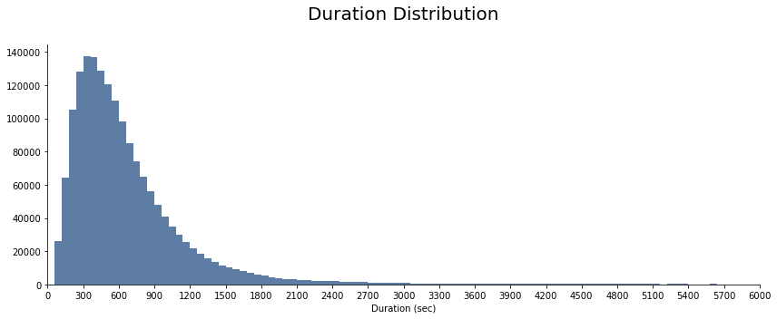

```python
# Set bin size and color
bin_size = 60
bins = np.arange(0, trips18_clean.duration_sec.max()+bin_size, bin_size)
color = sb.color_palette('viridis')[1]

# Plotting
fig, axes = plt.subplots(figsize = (12,5))
plt.hist(trips18_clean.duration_sec, bins = bins, color= color, alpha=0.8);

# Aesthetic wrangling
plt.xticks(ticks = [x for x in range(0,6001,300)])
plt.title('Duration Distribution\n', size=20)
plt.xlabel('Duration (sec)')
plt.xlim(0,6000)
sb.despine(fig)
plt.tight_layout();
```

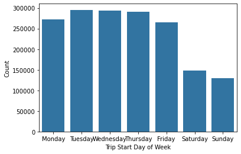

```python
# trip distribution over weekdays

weekday = ['Monday', 'Tuesday', 'Wednesday', 'Thursday', 'Friday', 'Saturday', 'Sunday']
weekdaycat = pd.api.types.CategoricalDtype(ordered=True, categories=weekday)
trips18_clean['start_dayofweek'] = trips18_clean['start_dayofweek'].astype(weekdaycat)

sb.countplot(data=trips18_clean, x='start_dayofweek', color=base_color);
plt.xlabel('Trip Start Day of Week');
plt.ylabel('Count');
```

> Less trips are taken on the weekends as compared to weekdays.

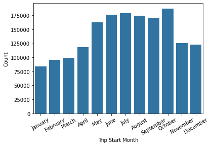

```python
# trip distribution over months

month = ['January', 'February', 'March', 'April', 'May', 'June', 'July', 'August', 'September', 'October', 'November', 'December']
monthcat = pd.api.types.CategoricalDtype(ordered=True, categories=month)
trips18_clean['start_month'] = trips18_clean['start_month'].astype(monthcat)

sb.countplot(data=trips18_clean, x='start_month', color=base_color);
plt.xticks(rotation=30);
plt.xlabel('Trip Start Month');
plt.ylabel('Count');
```

Looking in combined with the trip distribution over day of week plot, it is quite obvious that the majority of rides happened on work days (Mon-Fri) and primary usage is probably for commuting. In the 12 months in 2018, October had the most ride trips compared to the others, but overall it was the most popular during summer time (May-Sept), probably due to the weather in the area.

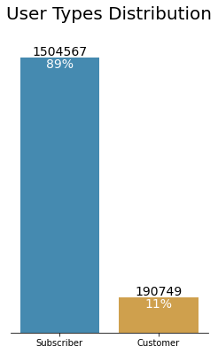

```python
# Plotting
fig, ax = plt.subplots(figsize = (4,6))
#color = sns.color_palette('colorblind')[10]
sb.countplot(x = "user_type", data = trips18_clean,
              order = trips18_clean['user_type'].value_counts().index,
              palette = sb.color_palette('colorblind'), alpha=0.8)
# Percentage for each age-group
perc_list = []

# Calculate % for 2 user types for each age_group
type_sum = trips18_clean['user_type'].value_counts().to_list()
total_sum = trips18_clean.shape[0]
# arrange the % list in same as annotate loop order
for i in range(0,len(type_sum)):
    percent = int(round(100 * type_sum[i] / total_sum))
    perc_list.append(percent)
# Annotate each bar
i=0
for p in ax.patches:
    ax.annotate('{:.0f}'.format(p.get_height()),
                (p.get_x()+p.get_width()/2, p.get_height()),
                ha="center", va="bottom", size=14)
    ax.annotate('{:.0f}%'.format(perc_list[i]),
                (p.get_x()+p.get_width()/2, p.get_height()),
                ha="center", va="top", color='white', size=14)
    i+=1

# Aesthetic wrangling
plt.title('User Types Distribution\n', size=20)
cur_axes = plt.gca()
cur_axes.axes.get_yaxis().set_visible(False)
sb.despine(fig, left = True)
plt.xlabel("");
```

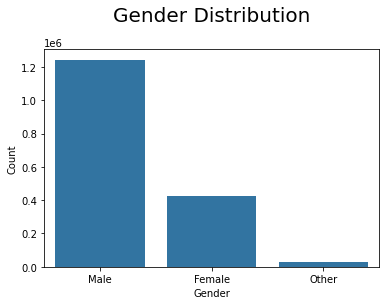

```python
sb.countplot(data=trips18_clean, x='member_gender', color=base_color);
plt.title('Gender Distribution\n', size=20)
plt.xlabel('Gender');
plt.ylabel('Count');
```

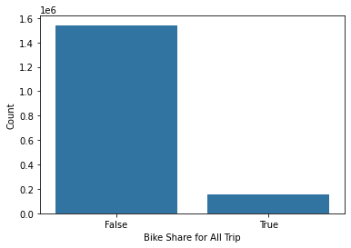

```python
sb.countplot(data=trips18_clean, x='bike_share_for_all_trip', color=base_color);
plt.xlabel('Bike Share for All Trip');
plt.ylabel('Count');
```

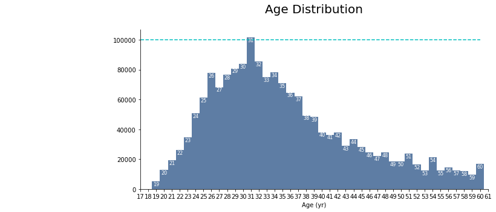

```python
# Set bin size equal to 1 yr and color
bin_size = 1
bins = np.arange(0, trips18_clean.member_age.max()+bin_size, bin_size)
color = sb.color_palette('viridis')[1]

# Plotting
fig, ax = plt.subplots(figsize = (12,5))
plt.hist(trips18_clean.member_age, bins = bins, color= color, align="left", alpha=0.8)
for p in ax.patches:
    ax.annotate('{:.0f}'.format(p.get_x()+0.5),
                (p.get_x()+p.get_width()/2, p.get_height()),
                ha='center', va='top', color = "white", size=8)

# Aesthetic wrangling
plt.xticks(ticks = [x for x in range(0,70,1)])
plt.xlim((17,61))
plt.title('Age Distribution\n', size=20)
plt.xlabel('Age (yr)')
plt.hlines(100000, 0, 60, colors = "c", linestyles = "dashed")
sb.despine(fig)
plt.tight_layout();
```

Most riders were male subscribers who did not use bike share for all trips. Most members were around 25 to 40 years old, corresponding to the trip distribution plots that most trips were on Mon-Fri and maxed during rush hours of a day. As the age gets older, bike usage dropped significantly.

Trip duration distribution to plot next.

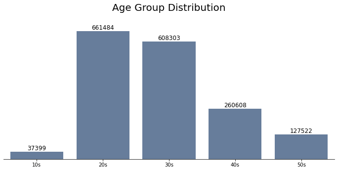

```python
# Plotting
fig, ax = plt.subplots(figsize = (12,5))
sb.countplot(x = "age_group", data = trips18_clean,
              color = sb.color_palette('viridis')[1],
              order = ['10s','20s','30s','40s','50s'],
              # order by age_group
              alpha=0.8)

# Aesthetic wrangling
for p in ax.patches:
    ax.annotate('{:.0f}'.format(p.get_height()),
                (p.get_x()+p.get_width()/2, p.get_height()),
                ha='center', va='bottom', color = "black", size=12)
plt.title('Age Group Distribution\n', size=20)
cur_axes = plt.gca()
cur_axes.axes.get_yaxis().set_visible(False)
sb.despine(fig, left = True)
plt.xlabel("");
```

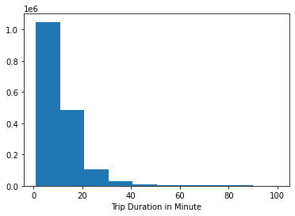

```python
plt.hist(data=trips18_clean, x='duration_minute');
plt.xlabel('Trip Duration in Minute');
```

```python
trips18_clean['duration_minute'].describe(percentiles=[.99])
```

```
count    1.695316e+06
mean     1.122244e+01
std      9.031355e+00
min      1.016667e+00
50%      9.000000e+00
99%      4.725000e+01
max      1.000000e+02
Name: duration_minute, dtype: float64
```

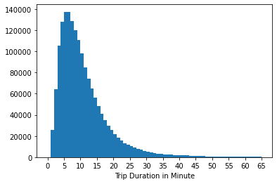

```python
bins = np.arange(0, 66, 1)
ticks = np.arange(0, 66, 5)
plt.hist(data=trips18_clean, x='duration_minute', bins=bins);
plt.xticks(ticks, ticks);
plt.xlabel('Trip Duration in Minute');
```

It looks like 99% of the trips were less than 1 hour long with most of them fell between 5 to 10 minutes range. I'll remove the outlier long trips for this study to allow focusing on the most common cases to explore the pattern.

```python
# issue 8: filter out outlier trip records where the duration was very long

trips18_clean = trips18_clean.query('duration_minute <= 66')
trips18_clean.info(null_counts=True)
```

```
<class 'pandas.core.frame.DataFrame'>
Int64Index: 1688410 entries, 6 to 1863719
Data columns (total 28 columns):
 #   Column                   Non-Null Count    Dtype
---  ------                   --------------    -----
 0   duration_sec             1688410 non-null  int64
 1   start_time               1688410 non-null  datetime64[ns]
 2   end_time                 1688410 non-null  datetime64[ns]
 3   start_station_id         1688410 non-null  int32
 4   start_station_name       1688410 non-null  object
 5   start_station_latitude   1688410 non-null  float64
 6   start_station_longitude  1688410 non-null  float64
 7   end_station_id           1688410 non-null  int32
 8   end_station_name         1688410 non-null  object
 9   end_station_latitude     1688410 non-null  float64
```

[output cut: 20 more lines]

```python
# Remove column name 'month' and weekday
trips18_clean = trips18_clean.drop(['month'], axis = 1)
trips18_clean = trips18_clean.drop(['weekday'], axis = 1)
```

```python
trips18_clean.info()
```

```
<class 'pandas.core.frame.DataFrame'>
Int64Index: 1688410 entries, 6 to 1863719
Data columns (total 26 columns):
 #   Column                   Non-Null Count    Dtype
---  ------                   --------------    -----
 0   duration_sec             1688410 non-null  int64
 1   start_time               1688410 non-null  datetime64[ns]
 2   end_time                 1688410 non-null  datetime64[ns]
 3   start_station_id         1688410 non-null  int32
 4   start_station_name       1688410 non-null  object
 5   start_station_latitude   1688410 non-null  float64
 6   start_station_longitude  1688410 non-null  float64
 7   end_station_id           1688410 non-null  int32
 8   end_station_name         1688410 non-null  object
 9   end_station_latitude     1688410 non-null  float64
```

[output cut: 18 more lines]

### Discuss the distribution(s) of your variable(s) of interest. Were there any unusual points? Did you need to perform any transformations?

There were more trips on work days (Mon-Fri) compared to weekends. Summar time was the most popular season of a year, likely due to the weather.

User-wise, there were more male riders than female, and most members were subscribers compared to casual riders. The majority of the members did not use bike share for all of their trips, and most were around 25 to 40 years old.

Most rides were quick and short, lasted between 5 to 10 minutes, though there were some very long outliers like 24hrs.

No transformation was needed luckily due to the straightforwardness of the data.

### Of the features you investigated, were there any unusual distributions? Did you perform any operations on the data to tidy, adjust, or change the form of the data? If so, why did you do this?

```python
# save the clean data to a .csv file

trips18_clean.to_csv('fordgobike_trips_2018_clean.csv', index=False)
```

## Bivariate Exploration

Average Trip Duration on Weekdays

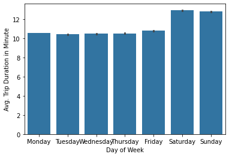

```python
sb.barplot(data=trips18_clean, x='start_dayofweek', y='duration_minute', color=base_color);
plt.xlabel('Day of Week');
plt.ylabel('Avg. Trip Duration in Minute');
```

The riding trips are much shorter on Monday through Friday compared to weekends. It indicates a pretty stable and efficient usage of the sharing system on normal work days, while more casual flexible use on weekends.

Average trip duration by month

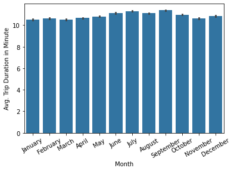

```python
sb.barplot(data=trips18_clean, x='start_month', y='duration_minute', color=base_color);
plt.xticks(rotation=30);
plt.xlabel('Month');
plt.ylabel('Avg. Trip Duration in Minute');
```

Member age by weekdays

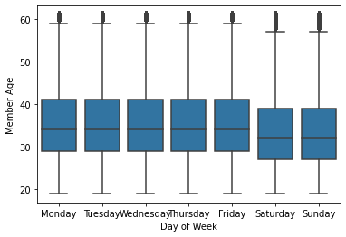

```python
sb.boxplot(data=trips18_clean, x='start_dayofweek', y='member_age', color=base_color);
plt.xlabel('Day of Week');
plt.ylabel('Member Age');
```

Riders who rented the bikes Monday through Friday are slightly older than those who ride on weekends, which corresponds to the commute to work usage that was observed from the above univariable exploration plots.

Weekly usage between customers and subscribers

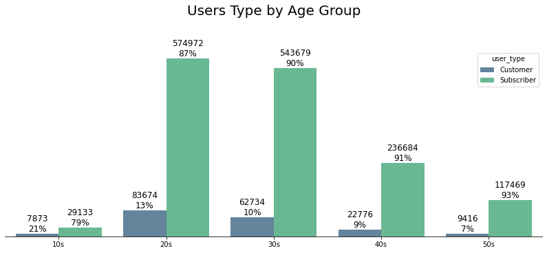

```python
fig, ax = plt.subplots(figsize = (14,5))

# Plotting
sb.countplot(x = "age_group", data = trips18_clean,
              palette = "viridis", hue = "user_type", alpha = 0.8)

# Percentage for each age-group
perc_list_customer, perc_list_subscriber, perc_list = [], [], []

# Calculate % for 2 user types for each age_group
type_sum = trips18_clean.groupby('age_group')['user_type'].value_counts().sort_index().to_list()
total_sum = trips18_clean['age_group'].value_counts().sort_index().to_list()

# arrange the % list in same as annotate loop order
for i in range(0,len(total_sum)):
    perc_customer = int(round(100 * type_sum[2*i] / total_sum[i]))
    perc_list_customer.append(perc_customer)
for i in range(0,len(total_sum)):
    perc_subscriber = int(round(100 * type_sum[2*i+1]/ total_sum[i]))
    perc_list_subscriber.append(perc_subscriber)
perc_list = perc_list_customer + perc_list_subscriber

# Annotate each bar
i=0
for p in ax.patches:
    ax.annotate('{:.0f}\n{:.0f}%'.format(p.get_height(), perc_list[i]),
                (p.get_x()+p.get_width()/2, p.get_height()),
                ha="center", va="bottom", size=12)
    i+=1

# Aesthetic wrangling
cur_axes = plt.gca()
cur_axes.axes.get_yaxis().set_visible(False)
sb.despine(fig, left = True)
plt.title("Users Type by Age Group\n\n", fontsize= 20)
plt.xlabel("");
```

> From graph above, user's subscription ratio increases as the age increase. Younger user tend to use the service but do not subscribe.

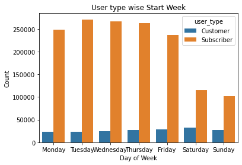

```python
sb.countplot(data=trips18_clean, x='start_dayofweek', hue='user_type');
plt.title('User type wise Start Week');
plt.xlabel('Day of Week');
plt.ylabel('Count');
```

There was much more subscriber usage than casual customers overall. The drop of volume on weekends for subscribers indicates that they primarily ride bikes for work commute during work days, whereas almost the opposite pattern of a slight increase of use for customers on weekends demonstrates that the use was more for leisure/touring and relaxing purposes.

Daily usage between customers and subscribers

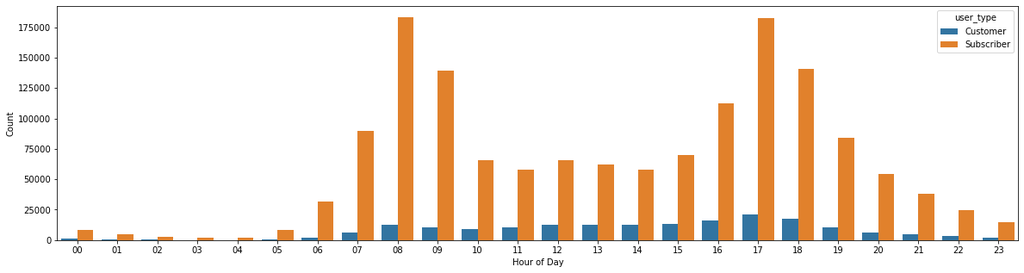

```python
plt.figure(figsize = [20, 5])
sb.countplot(data=trips18_clean, x='start_hourofday', hue='user_type');
plt.xlabel('Hour of Day');
plt.ylabel('Count');
```

Subscriber usage clearly peaks out on typical rush hours when people go to work in the morning and getting off work in the afternoon, double confirmed their usage purpose and goal of riding. Similar pattern was not observed among customers who tend to ride most in the afternoon or early evening as for a different purpose than the subscriber riders.

Yearly usage between customers and subscribers

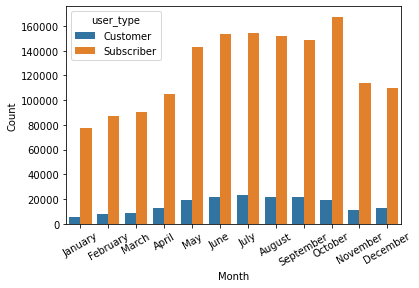

```python
sb.countplot(data=trips18_clean, x='start_month', hue='user_type');
plt.xticks(rotation=30);
plt.xlabel('Month');
plt.ylabel('Count');
```

Both subscribers and customers ride the most during the summer months with subscribers maxed out in October and customers peaked in July. The usage was clearly not popular during winter season like November, December and January likely due to the weather.

Member age between customers and subscribers

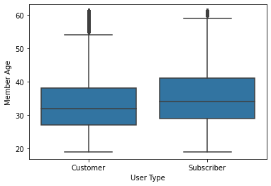

```python
sb.boxplot(data=trips18_clean, x='user_type', y='member_age', color=base_color);
plt.xlabel('User Type');
plt.ylabel('Member Age');
```

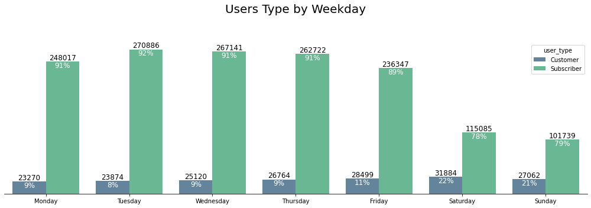

```python
fig, ax = plt.subplots(figsize = (14,5))
# Plotting
sb.countplot(x = "start_dayofweek", data = trips18_clean,
              palette = "viridis", hue = "user_type", alpha = 0.8)

# Percentage for each day
perc_list_customer, perc_list_subscriber, perc_list = [], [], []

# Calculate % for 2 user types for each day
type_sum = trips18_clean.groupby('start_dayofweek')['user_type'].value_counts().sort_index().to_list()
total_sum = trips18_clean['start_dayofweek'].value_counts().sort_index().to_list()

# arrange the % list in same as annotate loop order
for i in range(0,len(total_sum)):
    perc_customer = int(round(100 * type_sum[2*i] / total_sum[i]))
    perc_list_customer.append(perc_customer)
for i in range(0,len(total_sum)):
    perc_subscriber = int(round(100 * type_sum[2*i+1]/ total_sum[i]))
    perc_list_subscriber.append(perc_subscriber)
perc_list = perc_list_customer + perc_list_subscriber

# Annotate each bar
i=0
for p in ax.patches:
    ax.annotate('{:.0f}'.format(p.get_height()),
                (p.get_x()+p.get_width()/2, p.get_height()),
                ha="center", va="bottom", size=12)
    ax.annotate('{:.0f}%'.format(perc_list[i]),
                (p.get_x()+p.get_width()/2, p.get_height()),
                ha="center", va="top", color='white', size=12)
    i+=1

# Aesthetic wrangling
cur_axes = plt.gca()
cur_axes.axes.get_yaxis().set_visible(False)
sb.despine(fig, left = True)
plt.title("Users Type by Weekday\n\n", fontsize= 20)
plt.xlabel("")
plt.tight_layout();
```

> From graph above, Saturday and Sunday user populations have unusual low subscription ratio and total rides. This is probably due to people use the bike for work mostly.

### Did you observe any interesting relationships between the other features (not the main feature(s) of interest)?

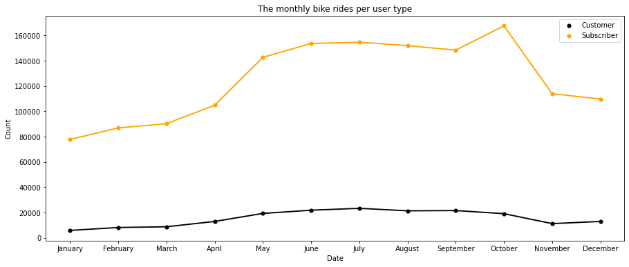

```python
user_type_count = trips18_clean.groupby(["start_month", "user_type"]).size().reset_index()
plt.figure(figsize=(15,6))
color = {'Subscriber':'orange', 'Customer':'black'}
axis = sb.pointplot(x='start_month', y=0, hue='user_type', palette=color, scale=.7, data=user_type_count)
plt.title('The monthly bike rides per user type')
plt.xlabel('Date')
plt.ylabel('Count')
plt.legend();
```

## Multivariate Exploration

#### How does the hourly usage vary during weekdays for customers and subscribers?

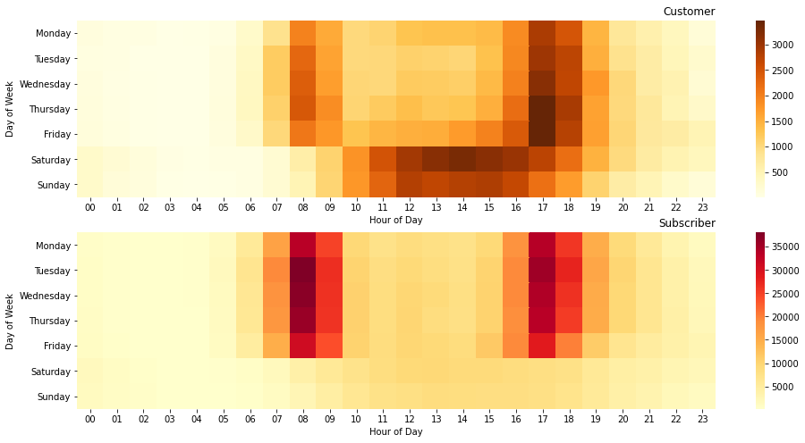

```python
plt.suptitle('Hourly Usage during Weekdays for Customers and Subscribers');
#fig, ax = plt.subplots(figsize=(5,5))

plt.figure(figsize = (16,8));
plt.subplot(2, 1, 1);
customers = trips18_clean.query('user_type == "Customer"');
ct_counts = customers.groupby(['start_dayofweek', 'start_hourofday']).size();
ct_counts = ct_counts.reset_index(name='count');
ct_counts = ct_counts.pivot(index='start_dayofweek', columns='start_hourofday', values='count');
sb.heatmap(ct_counts, cmap='YlOrBr');
plt.title('Customer', loc='right');
plt.xlabel('Hour of Day');
plt.ylabel('Day of Week');

plt.subplot(2, 1, 2);
subscribers = trips18_clean.query('user_type == "Subscriber"');
st_counts = subscribers.groupby(['start_dayofweek', 'start_hourofday']).size();
st_counts = st_counts.reset_index(name='count');
st_counts = st_counts.pivot(index='start_dayofweek', columns='start_hourofday', values='count');
sb.heatmap(st_counts, cmap='YlOrRd');
plt.title('Subscriber', loc='right');
plt.xlabel('Hour of Day');
plt.ylabel('Day of Week');
```

By the above heat map, we can see clearly the trips taken by customers and subscribers on weekdays and weekends.

### user_type for age_group by metro_area

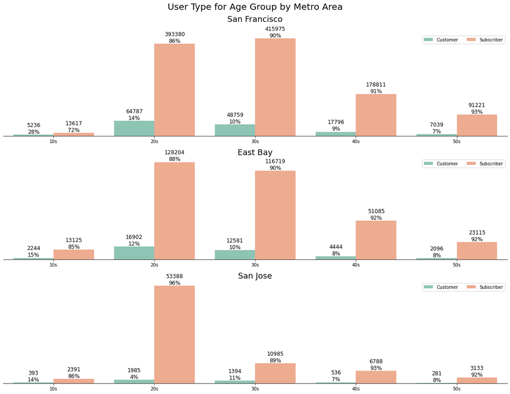

```python
# Since there's only three subplots to create, using the full data should be fine.
fig = plt.figure(figsize = [16, 12])

# Subplot 1: San Francisco, ride count for age_group by user_type
##############################################################
ax1 = plt.subplot(3, 1, 1)
ax1.set_title("San Francisco\n", size=18)
sb.countplot(data = trips18_clean.query('start_metro_area == "San Francisco"'),
              x = 'age_group', hue = 'user_type', palette = 'Set2', alpha=0.8)
plt.xlabel('')
plt.ylabel('')
cur_axes = plt.gca()
cur_axes.axes.get_yaxis().set_visible(False)
ax1.legend(loc = 1, ncol = 2)

# Percentage for each age_group
perc_list_customer, perc_list_subscriber, perc_list = [], [], []

# Calculate % for 2 user types for each age_group
type_sum = trips18_clean.query('start_metro_area == "San Francisco"').groupby('age_group')['user_type'].value_counts().sort_index().to_list()
total_sum = trips18_clean.query('start_metro_area == "San Francisco"')['age_group'].value_counts().sort_index().to_list()

# Arrange the % list in same as annotate loop order
for i in range(0,len(total_sum)):
    perc_customer = int(round(100 * type_sum[2*i] / total_sum[i]))
    perc_list_customer.append(perc_customer)
for i in range(0,len(total_sum)):
    perc_subscriber = int(round(100 * type_sum[2*i+1]/ total_sum[i]))
    perc_list_subscriber.append(perc_subscriber)
perc_list = perc_list_customer + perc_list_subscriber

# Add annotations
i=0
for p in ax1.patches:
    ax1.annotate('{:.0f}\n{:.0f}%'.format(p.get_height(), perc_list[i]),
                (p.get_x()+p.get_width()/2, p.get_height()),
                ha="center", va="bottom", size=12)
    i+=1

# Subplot 2: East Bay, ride count for age_group by user_type
##############################################################
ax2 = plt.subplot(3, 1, 2)
ax2.set_title("East Bay", size=18)
sb.countplot(data = trips18_clean.query('start_metro_area == "East Bay"'),
              x = 'age_group', hue = 'user_type', palette = "Set2", alpha=0.8)
plt.xlabel('')
plt.ylabel('')
cur_axes = plt.gca()
cur_axes.axes.get_yaxis().set_visible(False)
ax2.legend(loc = 1, ncol = 2)

# Percentage for each age_group
perc_list_customer, perc_list_subscriber, perc_list = [], [], []

# Calculate % for 2 user types for each age_group
type_sum = trips18_clean.query('start_metro_area == "East Bay"').groupby('age_group')['user_type'].value_counts().sort_index().to_list()
total_sum = trips18_clean.query('start_metro_area == "East Bay"')['age_group'].value_counts().sort_index().to_list()

# Arrange the % list in same as annotate loop order
for i in range(0,len(total_sum)):
    perc_customer = int(round(100 * type_sum[2*i] / total_sum[i]))
    perc_list_customer.append(perc_customer)
for i in range(0,len(total_sum)):
    perc_subscriber = int(round(100 * type_sum[2*i+1]/ total_sum[i]))
    perc_list_subscriber.append(perc_subscriber)
perc_list = perc_list_customer + perc_list_subscriber

# Add annotations
i=0
for p in ax2.patches:
    ax2.annotate('{:.0f}\n{:.0f}%'.format(p.get_height(), perc_list[i]),
                (p.get_x()+p.get_width()/2, p.get_height()),
                ha="center", va="bottom", size=12)
    i+=1

# Subplot 3: East Bay, ride count for age_group by user_type
##############################################################
ax3 = plt.subplot(3, 1, 3)
ax3.set_title("San Jose", size=18)
sb.countplot(data = trips18_clean.query('start_metro_area == "San Jose"'),
              x = 'age_group', hue = 'user_type', palette = 'Set2', alpha=0.8)
plt.xlabel('')
plt.ylabel('')
cur_axes = plt.gca()
cur_axes.axes.get_yaxis().set_visible(False)
ax3.legend(loc = 1, ncol = 2)
# Percentage for each age_group
perc_list_customer, perc_list_subscriber, perc_list = [], [], []

# Calculate % for 2 user types for each age_group
type_sum = trips18_clean.query('start_metro_area == "San Jose"').groupby('age_group')['user_type'].value_counts().sort_index().to_list()
total_sum = trips18_clean.query('start_metro_area == "San Jose"')['age_group'].value_counts().sort_index().to_list()

# Arrange the % list in same as annotate loop order
for i in range(0,len(total_sum)):
    perc_customer = int(round(100 * type_sum[2*i] / total_sum[i]))
    perc_list_customer.append(perc_customer)
for i in range(0,len(total_sum)):
    perc_subscriber = int(round(100 * type_sum[2*i+1]/ total_sum[i]))
    perc_list_subscriber.append(perc_subscriber)
perc_list = perc_list_customer + perc_list_subscriber

# Add annotations
i=0
for p in ax3.patches:
    ax3.annotate('{:.0f}\n{:.0f}%'.format(p.get_height(), perc_list[i]),
                (p.get_x()+p.get_width()/2, p.get_height()),
                ha="center", va="bottom", size=12)
    i+=1

# Aesthetic Wrangling
fig.suptitle('User Type for Age Group by Metro Area', size=20, y=1.02)
sb.despine(fig, left = True)
plt.tight_layout();
```

### Conclusion

**The relationship between the multiple variables plotted are visualized altogether and information are presented. The short period of usage for subscribers corresponds to their high concentration on rush hours Monday through Friday,which is for for work. The customer use shows that they're taking advantage of the bike sharing system quite differently from the subscribers, heavily over weekends and in the afternoon, for city tour or leisure purpose mostly.**

**The interactions between features are all supplementing each other and quite make sense when looked at combined, there's no big surprise observed.**